# Violent Analysis

GSD

May 15, 2018

# 1 Introduction

The dataset is about the violence unleashed by gun’s which are in the hands of people.This dataset provides an excellent platform to analyse various features and factors relating to gun violence and it can reveal hidden patterns once mined.

Lets get started

# 2 Loading the libraries & dataset

We load the dataset and take a look at the dimensions.

```r
library(tidyverse)
library(janitor)
library(zoo)
library(data.table)
library(VIM)
library(gridExtra)
library(splitstackshape)
library(DescTools)
library(quanteda)
library(tm)
library(tidytext)
gun=fread("gun-violence-data_01-2013_03-2018.csv",header=TRUE,stringsAsFactors = FALSE)
```

[output not shown]

```r
dim(gun)
```

```
## [1] 239677     29
```

From the dimensions we understand that the dataset consist of 29 features or columns and has more than 2L line items.Let us inspect the null values in each colums and also the summary of the data.

```r
summary(gun)
```

```
##   incident_id          date              state
##  Min.   :  92114   Length:239677      Length:239677
##  1st Qu.: 308545   Class :character   Class :character
##  Median : 543587   Mode  :character   Mode  :character
##  Mean   : 559334
##  3rd Qu.: 817228
##  Max.   :1083472
##
##  city_or_county       address             n_killed         n_injured
##  Length:239677      Length:239677      Min.   : 0.0000   Min.   : 0.000
##  Class :character   Class :character   1st Qu.: 0.0000   1st Qu.: 0.000
##  Mode  :character   Mode  :character   Median : 0.0000   Median : 0.000
##                                        Mean   : 0.2523   Mean   : 0.494
##                                        3rd Qu.: 0.0000   3rd Qu.: 1.000
##                                        Max.   :50.0000   Max.   :53.000
##
##  incident_url        source_url        incident_url_fields_missing
##  Length:239677      Length:239677      Mode :logical
##  Class :character   Class :character   FALSE:239677
##  Mode  :character   Mode  :character
##
##
##
##
##  congressional_district  gun_stolen          gun_type
##  Min.   : 0.000         Length:239677      Length:239677
##  1st Qu.: 2.000         Class :character   Class :character
##  Median : 5.000         Mode  :character   Mode  :character
##  Mean   : 8.001
##  3rd Qu.:10.000
##  Max.   :53.000
##  NA's   :11944
##  incident_characteristics    latitude     location_description
##  Length:239677            Min.   :19.11   Length:239677
##  Class :character         1st Qu.:33.90   Class :character
##  Mode  :character         Median :38.57   Mode  :character
##                           Mean   :37.55
##                           3rd Qu.:41.44
##                           Max.   :71.34
##                           NA's   :7923
```

[output cut: 17 more lines]

```
##  Length:239677            Length:239677      Length:239677
##  Class :character         Class :character   Class :character
##  Mode  :character         Mode  :character   Mode  :character
##
##
##
##
##    sources          state_house_district state_senate_district
##  Length:239677      Min.   :  1.00       Min.   : 1.00
##  Class :character   1st Qu.: 21.00       1st Qu.: 9.00
##  Mode  :character   Median : 47.00       Median :19.00
##                     Mean   : 55.45       Mean   :20.48
##                     3rd Qu.: 84.00       3rd Qu.:30.00
##                     Max.   :901.00       Max.   :94.00
##                     NA's   :38772        NA's   :32335
```

The dataset variables are explained as follows:

- Incident Id - Unique ID to each incident
- date - Date of incident occurence
- State - State where incident happened
- City or Country - Country or city where incident took place
- Address - Location of crime
- n_killed - Number of people killed
- n_injured - Number of people injured
- incident_url - URL Describing the incident
- source_url - Same as incident_url (‘dataset description doesnt provide much info.Therefore we assume’)
- incident_url_fields_missing- Logical indicating whether incident URL is present or not (‘dataset description doesnt provide much info.Therefore we assume’)
- congressional_district - District number (assume)
- gun_stolen- Status indicating whether the person had his/her gun stolen.
- gun_type - Type of gun
- incident_characteristics - Description of incident.
- latitute- Latitude of the area where crime happened.
- location_description - Place where incident took place.
- longitute - Longitude of the area where crime happened.
- n_guns_involved - Total guns involved in crime
- notes - Comments
- participant_age - Age of people involved
- participant_age_group - Age bracket of the people involved
- participant_gender- Gender of involved people
- participant_name - Name of the involved people
- Participant_relationship - Relationship of the group
- participant_status - status of the people - either arrested,injured or killed in the incident
- participant_type - Either he is a victim or suspect
- sources - Source of the incident information
- state_house_district - state house district Number
- state_senate_district - State senate district number

# 3 Data Cleaning

Before we dive into exploratory analysis,it is important that the data is cleaned to extract meaningful insights.Let us address the following problems one by one * Converting to factor variables & handling dates * Removing useless informations * Handling missing values

## 3.1 Converting to factor variables & handling dates

From the glimpse of the data we understand that there are some explicit variables that need to be treated as factors.Let us use the following code to covert them.

```r
factor_explicit =c("state","city_or_county")
gun[,(factor_explicit):=lapply(.SD,factor),.SDcols=factor_explicit]
sapply(gun,class)
```

```
##                 incident_id                        date
##                   "integer"                 "character"
##                       state              city_or_county
##                    "factor"                    "factor"
##                     address                    n_killed
##                 "character"                   "integer"
##                   n_injured                incident_url
##                   "integer"                 "character"
##                  source_url incident_url_fields_missing
##                 "character"                   "logical"
##      congressional_district                  gun_stolen
##                   "integer"                 "character"
##                    gun_type    incident_characteristics
##                 "character"                 "character"
##                    latitude        location_description
##                   "numeric"                 "character"
##                   longitude             n_guns_involved
##                   "numeric"                   "integer"
##                       notes             participant_age
##                 "character"                 "character"
##       participant_age_group          participant_gender
##                 "character"                 "character"
##            participant_name    participant_relationship
##                 "character"                 "character"
##          participant_status            participant_type
##                 "character"                 "character"
##                     sources        state_house_district
##                 "character"                   "integer"
##       state_senate_district
##                   "integer"
```

For other columns,the data is provided such that both the factor levels and factor is in the same column seperated by || .We will use the `splitstackshape` package to deal with such columns.

But before that let us focus on the date column and convert them into proper date format from character.Lets first get the top 5 row items from date field.

```r
head(gun$date)
```

```
## [1] "2013-01-01" "2013-01-01" "2013-01-01" "2013-01-05" "2013-01-07"
## [6] "2013-01-07"
```

Perfect.Now using standard package,

```r
gun$date_formated=as.Date(gun$date,format="%Y-%m-%d")
head(gun$date_formated)
```

```
## [1] "2013-01-01" "2013-01-01" "2013-01-01" "2013-01-05" "2013-01-07"
## [6] "2013-01-07"
```

## 3.2 Removing useless information

We find that there are some columns which might be unnecessary for our exploratory data analysis.According to me,I would remove sources,incident_url,source_url,incident_url_fields_missing from the dataframe.Lets remove it,

```r
remove <- c("sources","source_url","incident_url_fields_missing","incident_url")
gun[,(remove):=NULL]
names(gun)
```

```
##  [1] "incident_id"              "date"
##  [3] "state"                    "city_or_county"
##  [5] "address"                  "n_killed"
##  [7] "n_injured"                "congressional_district"
##  [9] "gun_stolen"               "gun_type"
## [11] "incident_characteristics" "latitude"
## [13] "location_description"     "longitude"
## [15] "n_guns_involved"          "notes"
## [17] "participant_age"          "participant_age_group"
## [19] "participant_gender"       "participant_name"
## [21] "participant_relationship" "participant_status"
## [23] "participant_type"         "state_house_district"
## [25] "state_senate_district"    "date_formated"
```

Perfect.Lets move on,

## 3.3 Handling Missing Values :

Let us see now how many columns have missing values in them and their count.

```r
na_values <-gun %>% map_dbl(~sum(is.na(.)))
round((na_values/nrow(gun))*100,2)
```

```
##              incident_id                     date                    state
##                     0.00                     0.00                     0.00
##           city_or_county                  address                 n_killed
##                     0.00                     0.00                     0.00
##                n_injured   congressional_district               gun_stolen
##                     0.00                     4.98                     0.00
##                 gun_type incident_characteristics                 latitude
##                     0.00                     0.00                     3.31
##     location_description                longitude          n_guns_involved
##                     0.00                     3.31                    41.49
##                    notes          participant_age    participant_age_group
##                     0.00                     0.00                     0.00
##       participant_gender         participant_name participant_relationship
##                     0.00                     0.00                     0.00
##       participant_status         participant_type     state_house_district
##                     0.00                     0.00                    16.18
##    state_senate_district            date_formated
##                    13.49                     0.00
```

From the proportion of missing values summary it is understood that the dataset is having heavy missing values.Lets visualise them to understand better.

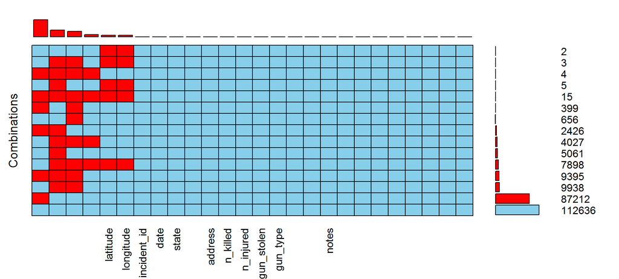

```
##
##  Variables sorted by number of missings:
##                  Variable Count
##           n_guns_involved 99451
##      state_house_district 38772
##     state_senate_district 32335
##    congressional_district 11944
##                  latitude  7923
##                 longitude  7923
##               incident_id     0
##                      date     0
##                     state     0
##            city_or_county     0
##                   address     0
##                  n_killed     0
##                 n_injured     0
##                gun_stolen     0
##                  gun_type     0
##  incident_characteristics     0
##      location_description     0
##                     notes     0
##           participant_age     0
##     participant_age_group     0
##        participant_gender     0
##          participant_name     0
##  participant_relationship     0
##        participant_status     0
##          participant_type     0
##             date_formated     0
```

```r
aggr(gun, prop = FALSE, combined = TRUE, numbers = TRUE, sortVars = TRUE, sortCombs = TRUE)
```

The table gives a summary of the missing values sorted in descending order whereas the visual represents the combination of missing values in each column.

We also find that except for n_guns_involved column which has 41 % of missing values all the other proportions of missing values in the column is lower.

Lets start our most interesting part …

# 4 Exploratory Data Analysis:

```r
theme_function=function() {theme_bw()+theme(legend.position="none",plot.title=element_text(size=16,hjust=0.5),axis.text.x=element_text(angle=90))}
```

## 4.1 Distribution of Incidents over state:

We want to get a birdseye view of the number of incidents that have taken place over the state.Lets visualise them.

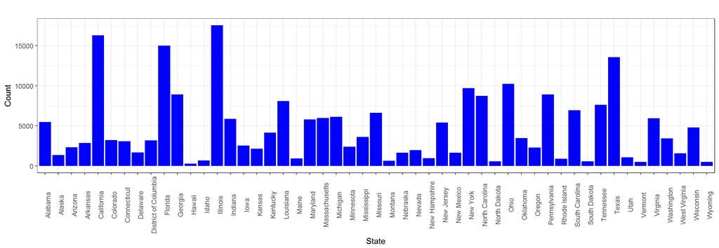

```r
ggplot(gun,aes(state,..count..))+geom_histogram(stat="count",fill="blue")+theme_function()+labs(x="State",y="Count",title="")
```

## 4.2 Trend of incidents over time.

Lets understand whether there were any patterns in the incidents over the year,month.

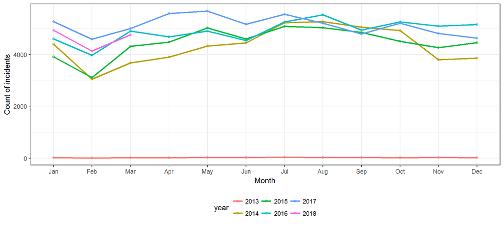

```r
gun$year=as.factor((year(gun$date)))
gun$month=lubridate::month(gun$date,label=TRUE,abbr=TRUE)
#temp=gun %>% group_by(year) %>% summarise(count=n())
temp=gun %>% group_by(year,month) %>% summarise(count=n())
ggplot(temp,aes(month,count,color=year))+geom_line(aes(group=year),size=0.9)+geom_point(alpha=0.5)+theme_bw()+theme(legend.position="bottom")+labs(x="Month",y="Count of incidents")
```

The data is consistent for the years 2015 to 2016.For 2018 we have only 3 month data.Is there any daily trend ? Lets find out.

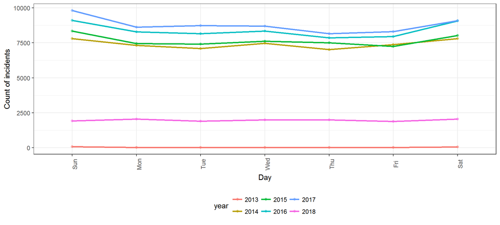

```r
gun$day=lubridate::wday(gun$date,label=TRUE,abbr=TRUE)

temp=gun %>% group_by(year,day) %>% summarise(count=n())
ggplot(temp,aes(day,count,color=year))+geom_line(aes(group=year),size=0.9)+geom_point(alpha=0.5)+theme_bw()+theme(legend.position="bottom",axis.text.x = element_text(angle=90))+labs(x="Day",y="Count of incidents")
```

We find that for the years 2018 and 2013 ,we cant conclude anything since the data is incomplete.

## 4.3 Time Series for Number of people killed and injured:

Let us now visualise the number of people killed or injured in the incident as a function of time.

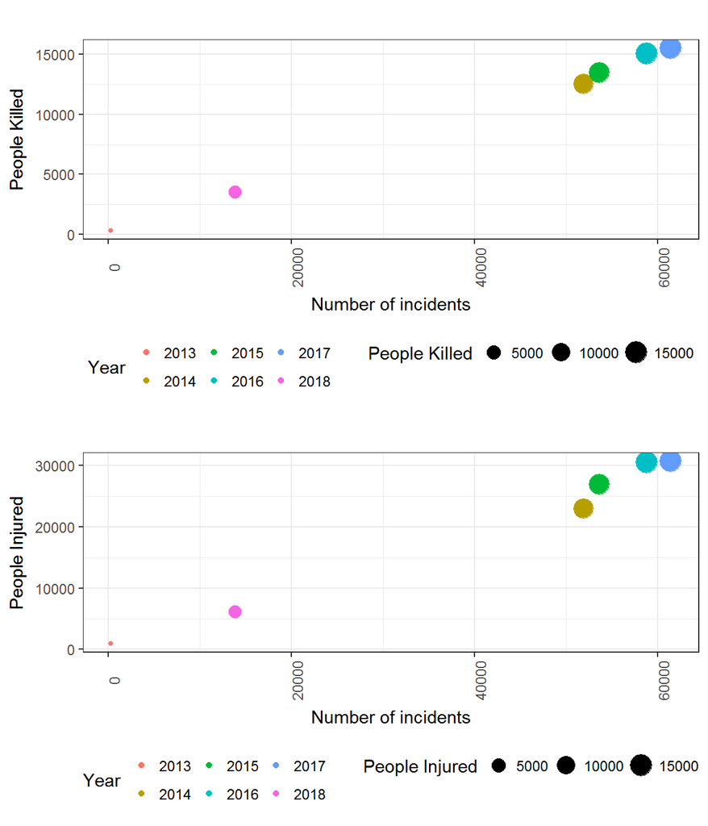

```r
temp = gun %>% group_by(year) %>% summarise(people_killed=sum(n_killed),people_injured=sum(n_injured),number_of_incidents=n())
g1=ggplot(temp,aes(number_of_incidents,people_killed))+geom_point(aes(size=people_killed,col=year))+theme_function()+theme(legend.position="bottom")+labs(x="Number of incidents",y="People Killed",title="",size="People Killed",col="Year")
g2=ggplot(temp,aes(number_of_incidents,people_injured))+geom_point(aes(size=people_killed,col=year))+theme_function()+theme(legend.position="bottom")+labs(x="Number of incidents",y="People Injured",title="",size="People Injured",col="Year")
grid.arrange(g1,g2,nrow=2)
```

We find that there is a perfect cause and effect relationship.As the number of incidents rises ,the number of people injured or killed has rised for the year.This is nothing strange and is very normal.

## 4.4 Age distribution of preparators

We want to find out how the preparators age is distributed.

Now lets have a sneek peak of the column where the age details are present.

```r
head(gun$participant_age)
```

```
## [1] "0::20"                             "0::20"
## [3] "0::25||1::31||2::33||3::34||4::33" "0::29||1::33||2::56||3::33"
## [5] "0::18||1::46||2::14||3::47"        "0::23||1::23||2::33||3::55"
```

Hmm,inorder to have a histogram we require some cleaning in this colum.This is where `splitstackshape` comes handy.Refer the code below where i do the cleaning part.This package presents some advantages in these situations where we need to split a row having multiple values into rows having only one value each.What makes it different is that the functions are capable of handling rows that have multiple values whose count is different. Have a look at my other [kernel](https://www.kaggle.com/gsdeepakkumar/startup-funding) where I have applied this package for analysis.

```r
age=cSplit(gun,c("participant_age"),sep="||",direction="long",drop=FALSE)
age$age_split=gsub(".*::","",age$participant_age)
age$age=as.numeric(age$age)
head(age$age)
```

```
## [1] 20 20 25 31 33 34
```

Perfect.Now lets do the visualisation and infer the findings.

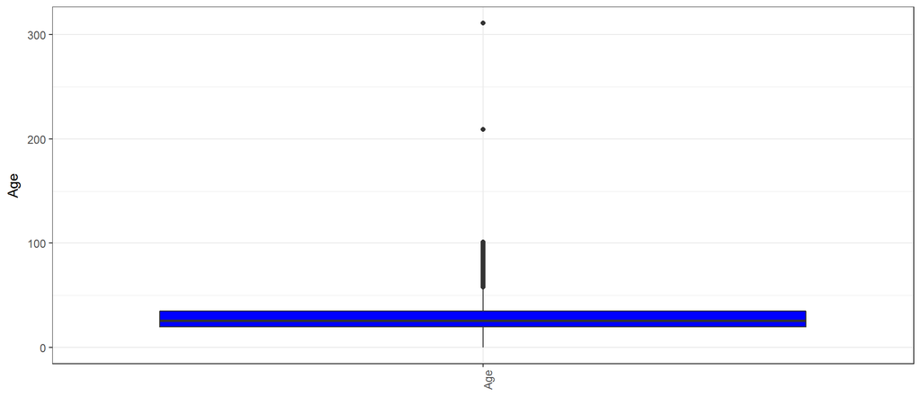

```r
ggplot(age,aes(x="Age",age))+geom_boxplot(fill="blue")+theme_function()+labs(x="",y="Age")
```

## 4.5 Gun Type

Now let us use the same method to know about the type of gun used.

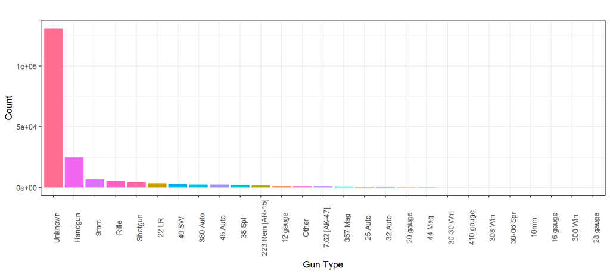

```r
gun_type=cSplit(gun,c("gun_type"),sep="||",direction="long",drop=FALSE)
gun_type$type_split=gsub(".*:","",gun_type$gun_type)
temp= gun_type %>% group_by(type_split) %>% summarise(count=n())%>% arrange(desc(count))
ggplot(temp,aes(factor(type_split,type_split),count,fill=type_split))+geom_bar(stat="identity")+theme_function()+labs(x="Gun Type",y="Count",title="")
```

We see that there are many instances where the gun type was unknown.Handgun,9mm pistol and Rifle were used by preparators.

## 4.6 Incident Characteristics:

Lets visualise the characteristics of each incident.

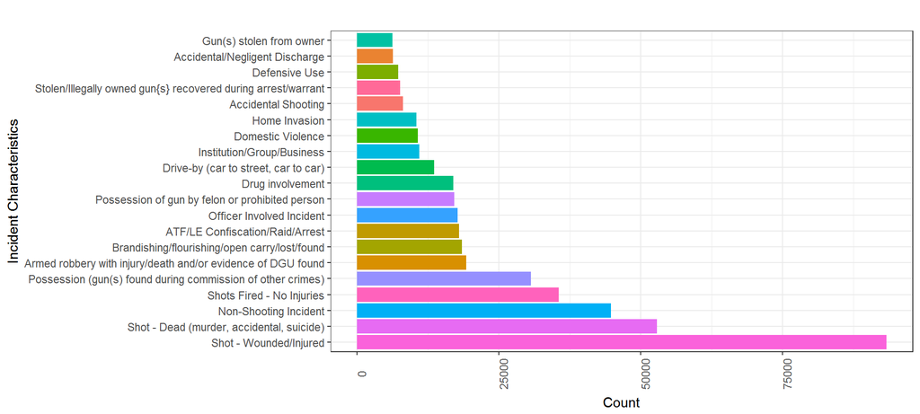

```r
incident_chara=cSplit(gun,c("incident_characteristics"),sep="||",direction="long",drop=FALSE)
temp= incident_chara %>% group_by(incident_characteristics) %>% summarise(count=n())%>% arrange(desc(count))
ggplot(head(temp,20),aes(factor(incident_characteristics,incident_characteristics),count,fill=incident_characteristics))+geom_bar(stat="identity")+theme_function()+labs(x="Incident Characteristics",y="Count",title="")+coord_flip()
```

Since the output gave 600+ types,I visualized the top 20 characteristics.We see that most of the time the person is injured or died once shot.And there were also many cases where the incident was non-shooting or persons escaped with no injuries.

## 4.7 Participant status:

It is important to know what happened after the incident happened.The dataset provides information about the type of participant(either victim or suspect) and what the person’s status was after the incident.Lets use these features to visualise and understand the scenario.

Since splitting both the columns runs to several millions,I restrict the analysis to univariate and to the year that has seen highest incidents. = 2017

```r
gun_filter= gun %>% filter(year=='2017')
type=cSplit(gun_filter,c("participant_status"),sep="||",direction="long",drop=TRUE)
type$participant_status=gsub(".*:","",type$participant_status)
head(type$participant_status)
```

```
## [1] "Killed"             "Unharmed, Arrested" "Unharmed, Arrested"
## [4] "Unharmed, Arrested" "Injured"            "Unharmed, Arrested"
```

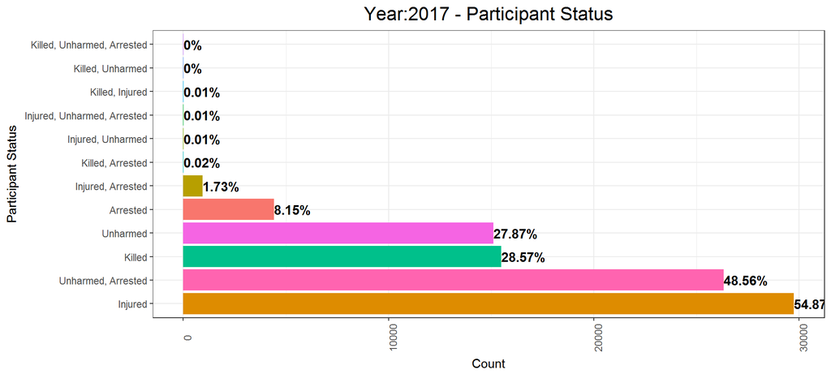

```r
total=length(unique(type$incident_id))
temp = type %>% group_by(participant_status) %>% summarise(count=n()) %>% mutate(perc=round((count/total)*100,2)) %>% arrange(desc(count))
ggplot(temp,aes(factor(participant_status,participant_status),count,fill=participant_status))+geom_bar(stat="identity")+theme_function()+geom_text(aes(label=paste0(perc,"%",sep=" ")),hjust=0,vjust=0.5,size=4,color='black',fontface='bold')+labs(x="Participant Status",y="Count",title='Year:2017 - Participant Status')+coord_flip()
```

As infered from previous graphs,we find that nearly in half of the instances people were injured followed closely by arrest.28 % of the people were killed where as nearly same amount were unharmed.

# 5 Text Analytics

Next with the notes column we do some text analysis.Here I will be extensively using functions from package `quanteda` which i stumbled upon a few months back !!! .It has some very good functions for text analytics.

For the purpose of analysis,let us extract notes column into a seperate df.

```r
text=gun$notes
head(text)
```

```
## [1] "Julian Sims under investigation: Four Shot and Injured"
## [2] "Four Shot; One Killed; Unidentified shooter in getaway car"
## [3] ""
## [4] ""
## [5] "Two firearms recovered. (Attempted) murder suicide - both succeeded in fulfilling an M/S and did not succeed, based on details."
## [6] ""
```

Now for creating a wordcloud,lets create a corpus from the text.

```r
corp=corpus(text)
head(summary(corp))
```

```
##    Text Types Tokens Sentences
## 1 text1     9      9         1
## 2 text2    10     11         1
## 3 text3     0      0         0
## 4 text4     0      0         0
## 5 text5    26     27         2
## 6 text6     0      0         0
```

## 5.1 Analysing some keywords:

`quanteda` provides a function called `kwic` which expands to keyword in context.Lets analyse the text with keywords - `killed`,`police`,`terrorist` and see if there are any hits.We pass this to the function as a vector and extract the output.Pls refer the code for more details.I have given a regex type of match which means that even a partial match of the keyword will be thrown out.

```r
kw <- c('killed','police','terrorist')
head(kwic(corp,phrase(kw),window=2,valuetype="regex"),10)
```

```
##
##    [text2, 5]      ; One | Killed  | ; Unidentified
##  [text10, 10] victim was | killed  | as he
##  [text21, 11]     - perp | killed  | two,
##   [text23, 2]       Aoki | killed  | in Ladera
##  [text37, 19] K9 officer | killed  | outside Glory
##  [text37, 28]    shot by | police  | Thurs.
##   [text45, 2]  Hernandez | killed  | in incident
##   [text63, 1]            | 2killed | ; 2
##   [text69, 2]          3 | killed  | ; 1
##   [text70, 5]       ms 4 | killed  | . Drug
```

Thus we find that the mentioned keywords find a place in the notes .

## 5.2 Wordcloud:

Now ,lets visualise the text using the wordcloud.

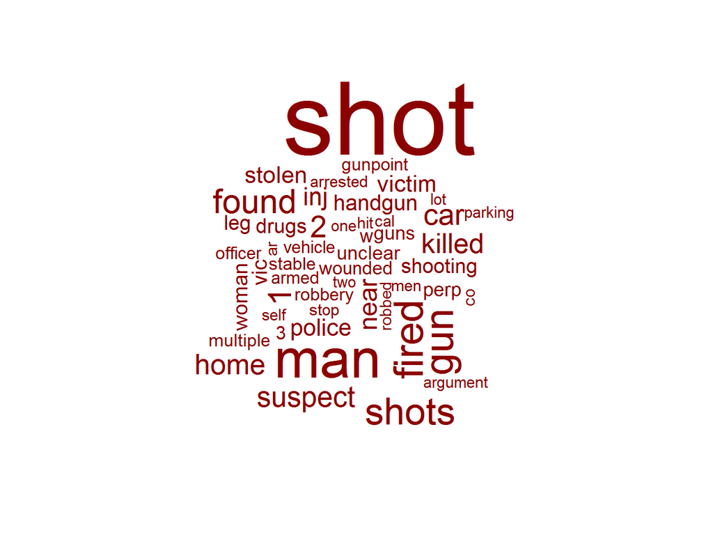

```r
wc <- corp %>% dfm(remove=stopwords('en'),remove_punct=TRUE)
set.seed(100)
textplot_wordcloud(wc,random_color = TRUE,max_count=10,random_order=TRUE,rotation=0.2,max_words = 50,color="darkred",max_size = 8,min_size = 0.8)
```

## 5.3 Topic Modelling

Now that we are done with the keyword search lets play with the text and find out whether the words echo more than one theme.

```r
topic <- dfm(corp,verbose = FALSE,remove_punct=TRUE,remove=stopwords('en'))
dtm <- convert(topic,to="topicmodels")
lda <- topicmodels::LDA(dtm,k=2,control=list(seed=100))
gun_topics <- tidy(lda,matrix="beta")
```

Now that we have applied LDA lets visualise,

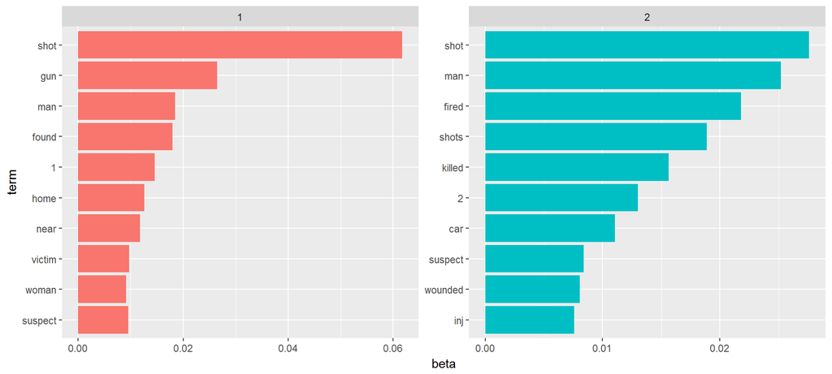

```r
topic_top_terms <- gun_topics %>%
  group_by(topic) %>%
  top_n(10, beta) %>%
  ungroup() %>%
  arrange(topic, -beta)

topic_top_terms %>%
  mutate(term = reorder(term, beta)) %>%
  ggplot(aes(term, beta, fill = factor(topic))) +
  geom_col(show.legend = FALSE) +
  facet_wrap(~ topic, scales = "free") +
  coord_flip()
```

From the visuals,we understand that the top 3 words in the 2 groups have been more or less the same meaning that all the incidents have one characteristic in particular that can be expressed in only one way.

# 6 Conclusion

Thus with this dataset we analysed various factors that were tied to the gun violence and made text analysis to mine some valuable insights.The dataset presented an unique challenge where there were few columns having row values that were a mini row values in themselves !!!! . We used standard available libraries in r to tackle this problem and successfully ‘tidied’ the data for analysis pupose.